# Decorrelation-Based Feature Discovery: GRAVIER-Whole

Jose Tamez

2023-09-28

# 1 Effect of UPSTM-Based Decorrelation on Feature Discovery

### 1.0.1 Loading the libraries

```r
library("FRESA.CAD")
library(readxl)
library(igraph)
library(umap)
library(tsne)
library(entropy)

op <- par(no.readonly = TRUE)
pander::panderOptions('digits', 3)
pander::panderOptions('table.split.table', 400)
pander::panderOptions('keep.trailing.zeros',TRUE)
```

## 1.1 Material and Methods

## 1.2 The Data

```r
#data('gravier', package = 'datamicroarray')
#table(gravier$y)

load("~/GitHub/datamicroarray/data/gravier.RData")


gravierset <- as.data.frame(cbind(class=1*(gravier$y=="poor"),gravier$x))

gravier <- NULL
```

#### 1.2.0.1 Standarize the names for the reporting

```r
studyName <- "GRAVIER"
dataframe <- gravierset
outcome <- "class"

TopVariables <- 10

thro <- 0.80
cexheat = 0.15
```

## 1.3 Generaring the report

### 1.3.1 Libraries

Some libraries

```r
library(psych)
library(whitening)
library("vioplot")
library("rpart")
```

### 1.3.2 Data specs

```r
pander::pander(c(rows=nrow(dataframe),col=ncol(dataframe)-1))
```

| rows | col |
| --- | --- |
| 168 | 2905 |

```r
pander::pander(table(dataframe[,outcome]))
```

| 0 | 1 |
| --- | --- |
| 111 | 57 |

```r
varlist <- colnames(dataframe)
varlist <- varlist[varlist != outcome]

largeSet <- length(varlist) > 1500
```

### 1.3.3 Scaling the data

Scaling and removing near zero variance columns and highly co-linear(r>0.99999) columns

```r
  ### Some global cleaning
  sdiszero <- apply(dataframe,2,sd) > 1.0e-16
  dataframe <- dataframe[,sdiszero]

  varlist <- colnames(dataframe)[colnames(dataframe) != outcome]
  tokeep <- c(as.character(correlated_Remove(dataframe,varlist,thr=0.99999)),outcome)
  dataframe <- dataframe[,tokeep]

  varlist <- colnames(dataframe)
  varlist <- varlist[varlist != outcome]

  iscontinous <- sapply(apply(dataframe,2,unique),length) >= 5 ## Only variables with enough samples



dataframeScaled <- FRESAScale(dataframe,method="OrderLogit")$scaledData
```

## 1.4 The heatmap of the data

```r
numsub <- nrow(dataframe)
if (numsub > 1000) numsub <- 1000


if (!largeSet)
{

  hm <- heatMaps(data=dataframeScaled[1:numsub,],
                 Outcome=outcome,
                 Scale=TRUE,
                 hCluster = "row",
                 xlab="Feature",
                 ylab="Sample",
                 srtCol=45,
                 srtRow=45,
                 cexCol=cexheat,
                 cexRow=cexheat
                 )
  par(op)
}
```

#### 1.4.0.1 Correlation Matrix of the Data

The heat map of the data

```r
if (!largeSet)
{

  par(cex=0.6,cex.main=0.85,cex.axis=0.7)
  #cormat <- Rfast::cora(as.matrix(dataframe[,varlist]),large=TRUE)
  cormat <- cor(dataframe[,varlist],method="pearson")
  cormat[is.na(cormat)] <- 0
  gplots::heatmap.2(abs(cormat),
                    trace = "none",
  #                  scale = "row",
                    mar = c(5,5),
                    col=rev(heat.colors(5)),
                    main = "Original Correlation",
                    cexRow = cexheat,
                    cexCol = cexheat,
                     srtCol=45,
                     srtRow=45,
                    key.title=NA,
                    key.xlab="|Pearson Correlation|",
                    xlab="Feature", ylab="Feature")
  diag(cormat) <- 0
  print(max(abs(cormat)))
}
```

## 1.5 The decorrelation

```r
DEdataframe <- IDeA(dataframe,verbose=TRUE,thr=thro)
```

```
#>
#>  g1int824 g1int834 g1int1068 g4D02 g1int718 g1int1437
#>     g2E09     g7F07     g1A01     g3C09     g3H08     g1A08
#> 0.5660573 0.6764402 0.8092446 0.2290445 0.2017937 0.5905485
#>
#>  Included: 2899 , Uni p: 5.163511e-05 , Base Size: 2118 , Rcrit: 0.2950683
#>
#>
```

```r
 1 <R=0.983,thr=0.950>, Top: 6< 5 >[Fa= 6 ]( 6 , 14 , 0 ),<|>Tot Used: 20 , Added: 14 , Zero Std: 0 , Max Cor: 0.952
 2 <R=0.952,thr=0.950>, Top: 1< 1 >[Fa= 7 ]( 1 , 1 , 6 ),<|>Tot Used: 22 , Added: 1 , Zero Std: 0 , Max Cor: 0.950
 3 <R=0.950,thr=0.900>, Top: 51< 3 >[Fa= 54 ]( 51 , 82 , 7 ),<|>Tot Used: 149 , Added: 82 , Zero Std: 0 , Max Cor: 0.914
 4 <R=0.914,thr=0.900>, Top: 3< 1 >[Fa= 57 ]( 3 , 3 , 54 ),<|>Tot Used: 155 , Added: 3 , Zero Std: 0 , Max Cor: 0.900
 5 <R=0.900,thr=0.800>, Top: 204< 9 >..[Fa= 232 ]( 203 , 460 , 57 ),<|>Tot Used: 777 , Added: 460 , Zero Std: 0 , Max Cor: 0.897
 6 <R=0.897,thr=0.800>, Top: 42< 13 >[Fa= 271 ]( 42 , 74 , 232 ),<|>Tot Used: 887 , Added: 74 , Zero Std: 0 , Max Cor: 0.864
 7 <R=0.864,thr=0.800>, Top: 5< 3 >[Fa= 276 ]( 5 , 9 , 271 ),<|>Tot Used: 901 , Added: 9 , Zero Std: 0 , Max Cor: 0.800
 8 <R=0.800,thr=0.800>
 [ 8 ], 0.7999747 Decor Dimension: 901 Nused: 901 . Cor to Base: 618 , ABase: 2899 , Outcome Base: 0
varlistc <- colnames(DEdataframe)[colnames(DEdataframe) != outcome]

pander::pander(sum(apply(dataframe[,varlist],2,var)))
```

*61.1*

```r
pander::pander(sum(apply(DEdataframe[,varlistc],2,var)))
```

*46.4*

```r
pander::pander(entropy(discretize(unlist(dataframe[,varlist]), 256)))
```

*3*

```r
pander::pander(entropy(discretize(unlist(DEdataframe[,varlistc]), 256)))
```

*2.85*

### 1.5.1 The decorrelation matrix

```r
if (!largeSet)
{

  par(cex=0.6,cex.main=0.85,cex.axis=0.7)

  UPLTM <- attr(DEdataframe,"UPLTM")

  gplots::heatmap.2(1.0*(abs(UPLTM)>0),
                    trace = "none",
                    mar = c(5,5),
                    col=rev(heat.colors(5)),
                    main = "Decorrelation matrix",
                    cexRow = cexheat,
                    cexCol = cexheat,
                   srtCol=45,
                   srtRow=45,
                    key.title=NA,
                    key.xlab="|Beta|>0",
                    xlab="Output Feature", ylab="Input Feature")

  par(op)



}
```

### 1.5.2 Formulas Network

Displaying the features associations

```r
par(op)

if (ncol(dataframe) < 1000)
{

  DEdataframeB <- ILAA(dataframe,verbose=TRUE,thr=thro,bootstrap=30)

  transform <- 1*(attr(DEdataframeB,"UPLTM") != 0)
  print(ncol(transform))
  thrcol <- 1 + 0.025*nrow(transform)
  rsum <- apply(1*(transform !=0),1,sum) > 2
  csum <- apply(1*(transform !=0),2,sum) > thrcol | rsum
  transform <- transform[csum,csum]
  csum <- (apply(1*(transform !=0),2,sum) > 1) & (apply(1*(transform !=0),1,sum) > 1)
  transform <- transform[csum,csum]
  print(ncol(transform))
  if (ncol(transform)>100)
  {
    thrcol <- 1 + 0.10*nrow(transform)
    rsum <- apply(1*(transform !=0),1,sum) > 4
    csum <- apply(1*(transform !=0),2,sum) > thrcol | rsum
    transform <- transform[csum,csum]
    csum <- (apply(1*(transform !=0),2,sum) > 3) & (apply(1*(transform !=0),1,sum) > 3)
    transform <- transform[csum,csum]
  }
  print(ncol(transform))
  if (ncol(transform)>100)
  {
    thrcol <- 1 + 0.20*nrow(transform)
    rsum <- apply(1*(transform !=0),1,sum) > 8
    csum <- apply(1*(transform !=0),2,sum) > thrcol | rsum
    transform <- transform[csum,csum]
    csum <- (apply(1*(transform !=0),2,sum) > 7) & (apply(1*(transform !=0),1,sum) > 7)
    transform <- transform[csum,csum]
  }
  print(ncol(transform))

  if ((ncol(transform) > 10) && (ncol(transform) < 150))
  {

      gplots::heatmap.2(transform,
                    trace = "none",
                    mar = c(5,5),
                    col=rev(heat.colors(5)),
                    main = "Red Decorrelation matrix",
                    cexRow = cexheat,
                    cexCol = cexheat,
                   srtCol=45,
                   srtRow=45,
                    key.title=NA,
                    key.xlab="|Beta|>0",
                    xlab="Output Feature", ylab="Input Feature")

      par(op)


    colnames(transform) <- str_remove_all(colnames(transform),"La_")

    VertexSize <- apply(transform,2,mean)
    VertexSize <- 5*VertexSize/max(VertexSize)

    gr <- graph_from_adjacency_matrix(transform,mode = "directed",diag = FALSE,weighted=TRUE)
    gr$layout <- layout_with_fr

    fc <- cluster_optimal(gr)
    plot(fc, gr,
         edge.width = 0.5*E(gr)$weight,
         vertex.size=VertexSize,
         edge.arrow.size=0.5,
         edge.arrow.width=0.5,
         vertex.label.cex=0.65,
         vertex.label.dist=1,
         main="Feature Association")
  }
}

par(op)
```

## 1.6 The heatmap of the decorrelated data

```r
if (!largeSet)
{

  hm <- heatMaps(data=DEdataframe[1:numsub,],
                 Outcome=outcome,
                 Scale=TRUE,
                 hCluster = "row",
                 cexRow = cexheat,
                 cexCol = cexheat,
                 srtCol=45,
                 srtRow=45,
                 xlab="Feature",
                 ylab="Sample")
  par(op)
}
```

## 1.7 The correlation matrix after decorrelation

```r
if (!largeSet)
{

  cormat <- cor(DEdataframe[,varlistc],method="pearson")
  cormat[is.na(cormat)] <- 0

  gplots::heatmap.2(abs(cormat),
                    trace = "none",
                    mar = c(5,5),
                    col=rev(heat.colors(5)),
                    main = "Correlation after ILAA",
                    cexRow = cexheat,
                    cexCol = cexheat,
                     srtCol=45,
                     srtRow=45,
                    key.title=NA,
                    key.xlab="|Pearson Correlation|",
                    xlab="Feature", ylab="Feature")

  par(op)
  diag(cormat) <- 0
  print(max(abs(cormat)))
}
```

## 1.8 U-MAP Visualization of features

### 1.8.1 The UMAP based on LASSO on Raw Data

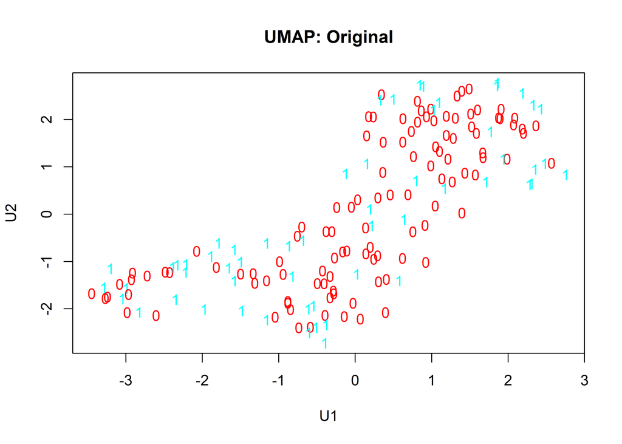

```r
if (nrow(dataframe) < 1000)
{
  classes <- unique(dataframe[1:numsub,outcome])
  raincolors <- rainbow(length(classes))
  names(raincolors) <- classes
  datasetframe.umap = umap(scale(dataframe[1:numsub,varlist]),n_components=2)
  plot(datasetframe.umap$layout,xlab="U1",ylab="U2",main="UMAP: Original",t='n')
  text(datasetframe.umap$layout,labels=dataframe[1:numsub,outcome],col=raincolors[dataframe[1:numsub,outcome]+1])
}
```

### 1.8.2 The decorralted UMAP

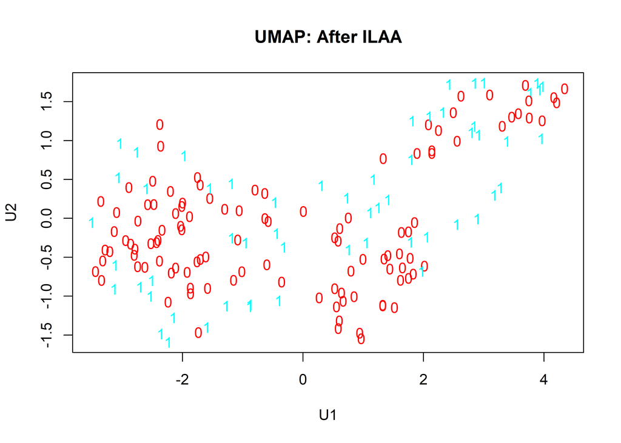

```r
if (nrow(dataframe) < 1000)
{

  datasetframe.umap = umap(scale(DEdataframe[1:numsub,varlistc]),n_components=2)
  plot(datasetframe.umap$layout,xlab="U1",ylab="U2",main="UMAP: After ILAA",t='n')
  text(datasetframe.umap$layout,labels=DEdataframe[1:numsub,outcome],col=raincolors[DEdataframe[1:numsub,outcome]+1])
}
```

## 1.9 Univariate Analysis

### 1.9.1 Univariate

```r
univarRAW <- uniRankVar(varlist,
               paste(outcome,"~1"),
               outcome,
               dataframe,
               rankingTest="AUC")
```

100 : g1A07 200 : g3H03 300 : g1E07 400 : g4F03 500 : g4C05  
600 : g1int292 700 : g1int356 800 : g7A03 900 : g4D11 1000 : g1int577  
1100 : g1CNS420 1200 : g7G07 1300 : g1int785 1400 : g1CNS59 1500 : g1CNS178  
1600 : g1int949 1700 : g1int1028 1800 : g1int1089 1900 : g11D05 2000 : g1int1222  
2100 : g1int1298 2200 : g1int1376 2300 : g1int1449 2400 : g10E08 2500 : g1CNS90  
2600 : g7F11 2700 : g1int1693 2800 : g1CNS93 2900 : g1int1800

```r
univarDe <- uniRankVar(varlistc,
               paste(outcome,"~1"),
               outcome,
               DEdataframe,
               rankingTest="AUC",
               )
```

100 : g1A07 200 : g3H03 300 : La_g1E07 400 : g4F03 500 : g4C05  
600 : La_g1int292 700 : g1int356 800 : g7A03 900 : g4D11 1000 : g1int577  
1100 : g1CNS420 1200 : La_g7G07 1300 : g1int785 1400 : La_g1CNS59 1500 : g1CNS178  
1600 : g1int949 1700 : La_g1int1028 1800 : La_g1int1089 1900 : g11D05 2000 : g1int1222  
2100 : g1int1298 2200 : g1int1376 2300 : La_g1int1449 2400 : g10E08 2500 : g1CNS90  
2600 : g7F11 2700 : g1int1693 2800 : La_g1CNS93 2900 : g1int1800

### 1.9.2 Final Table

```r
univariate_columns <- c("caseMean","caseStd","controlMean","controlStd","controlKSP","ROCAUC")

##top variables
topvar <- c(1:length(varlist)) <= TopVariables
tableRaw <- univarRAW$orderframe[topvar,univariate_columns]
pander::pander(tableRaw)
```

|  | caseMean | caseStd | controlMean | controlStd | controlKSP | ROCAUC |
| --- | --- | --- | --- | --- | --- | --- |
| **g1CNS507** | -0.250 | 0.222 | -0.0248 | 0.195 | 0.075349 | 0.796 |
| **g1CNS105** | 0.254 | 0.270 | 0.0533 | 0.172 | 0.009926 | 0.749 |
| **g1CNS382** | -0.171 | 0.173 | -0.0354 | 0.145 | 0.045504 | 0.745 |
| **g1int804** | -0.250 | 0.220 | -0.0775 | 0.205 | 0.020286 | 0.743 |
| **g1CNS91** | 0.310 | 0.294 | 0.0994 | 0.138 | 0.003638 | 0.742 |
| **g1CNS26** | -0.145 | 0.169 | -0.0101 | 0.125 | 0.657242 | 0.738 |
| **g1int340** | -0.157 | 0.183 | -0.0169 | 0.139 | 0.028840 | 0.737 |
| **g1CNS70** | 0.152 | 0.177 | 0.0352 | 0.115 | 0.022558 | 0.731 |
| **g1CNS158** | 0.260 | 0.251 | 0.1007 | 0.167 | 0.000401 | 0.731 |
| **g1CNS28** | 0.218 | 0.218 | 0.0744 | 0.143 | 0.001961 | 0.726 |

```r
topLAvar <- univarDe$orderframe$Name[str_detect(univarDe$orderframe$Name,"La_")]
topLAvar <- unique(c(univarDe$orderframe$Name[topvar],topLAvar[1:as.integer(TopVariables/2)]))
finalTable <- univarDe$orderframe[topLAvar,univariate_columns]


pander::pander(finalTable)
```

|  | caseMean | caseStd | controlMean | controlStd | controlKSP | ROCAUC |
| --- | --- | --- | --- | --- | --- | --- |
| **g1CNS507** | -0.249546 | 0.2224 | -0.024786 | 0.1946 | 0.075349 | 0.796 |
| **g1int340** | -0.157144 | 0.1829 | -0.016911 | 0.1391 | 0.028840 | 0.737 |
| **g8D02** | -0.086458 | 0.1772 | 0.027399 | 0.1370 | 0.019618 | 0.725 |
| **g1CNS159** | 0.192334 | 0.2488 | 0.046005 | 0.1735 | 0.000826 | 0.723 |
| **g1int1671** | 0.126334 | 0.1404 | 0.039686 | 0.1218 | 0.099178 | 0.719 |
| **g9E01** | 0.091105 | 0.1633 | -0.004645 | 0.0984 | 0.039398 | 0.717 |
| **g1int812** | -0.192608 | 0.2140 | -0.046220 | 0.1755 | 0.235071 | 0.716 |
| **g1CNS74** | 0.124918 | 0.1377 | 0.039057 | 0.1157 | 0.163757 | 0.716 |
| **g8F04** | 0.022967 | 0.0898 | -0.046750 | 0.0893 | 0.805754 | 0.710 |
| **g5G03** | -0.113922 | 0.1569 | -0.014816 | 0.1450 | 0.040736 | 0.706 |
| **La_g1int829** | 0.027457 | 0.0662 | -0.018160 | 0.0654 | 0.686753 | 0.700 |
| **La_g4F01** | 0.038348 | 0.0752 | -0.000825 | 0.0780 | 0.311967 | 0.677 |
| **La_g1int1102** | -0.075044 | 0.0969 | -0.020829 | 0.0888 | 0.626136 | 0.674 |
| **La_g6H03** | 0.000405 | 0.1480 | -0.045865 | 0.0647 | 0.370420 | 0.667 |
| **La_g1CNS91** | 0.081214 | 0.1814 | 0.012656 | 0.0845 | 0.130390 | 0.667 |

```r
dc <- getLatentCoefficients(DEdataframe)
fscores <- attr(DEdataframe,"fscore")


pander::pander(c(mean=mean(sapply(dc,length)),total=length(dc),fraction=length(dc)/(ncol(dataframe)-1)))
```

| mean | total | fraction |
| --- | --- | --- |
| 2 | 643 | 0.221 |

```r
theCharformulas <- attr(dc,"LatentCharFormulas")


finalTable <- rbind(finalTable,tableRaw[topvar[!(topvar %in% topLAvar)],univariate_columns])


orgnamez <- rownames(finalTable)
orgnamez <- str_remove_all(orgnamez,"La_")
finalTable$RAWAUC <- univarRAW$orderframe[orgnamez,"ROCAUC"]
finalTable$DecorFormula <- theCharformulas[rownames(finalTable)]
finalTable$fscores <- fscores[rownames(finalTable)]

Final_Columns <- c("DecorFormula","caseMean","caseStd","controlMean","controlStd","controlKSP","ROCAUC","RAWAUC","fscores")

finalTable <- finalTable[order(-finalTable$ROCAUC),]
pander::pander(finalTable[,Final_Columns])
```

|  | DecorFormula | caseMean | caseStd | controlMean | controlStd | controlKSP | ROCAUC | RAWAUC | fscores |
| --- | --- | --- | --- | --- | --- | --- | --- | --- | --- |
| **g1CNS507** | NA | -0.249546 | 0.2224 | -0.024786 | 0.1946 | 0.075349 | 0.796 | 0.796 | NA |
| **g1CNS5071** | NA | -0.249546 | 0.2224 | -0.024786 | 0.1946 | 0.075349 | 0.796 | NA | NA |
| **g1CNS105** | NA | 0.254206 | 0.2698 | 0.053317 | 0.1720 | 0.009926 | 0.749 | 0.749 | NA |
| **g1CNS382** | NA | -0.171019 | 0.1731 | -0.035377 | 0.1449 | 0.045504 | 0.745 | 0.745 | NA |
| **g1int804** | NA | -0.249725 | 0.2195 | -0.077451 | 0.2051 | 0.020286 | 0.743 | 0.743 | NA |
| **g1CNS91** | NA | 0.309879 | 0.2941 | 0.099384 | 0.1383 | 0.003638 | 0.742 | 0.742 | NA |
| **g1CNS26** | NA | -0.144676 | 0.1686 | -0.010129 | 0.1253 | 0.657242 | 0.738 | 0.738 | NA |
| **g1int340** | NA | -0.157144 | 0.1829 | -0.016911 | 0.1391 | 0.028840 | 0.737 | 0.737 | NA |
| **g1int3401** | NA | -0.157144 | 0.1829 | -0.016911 | 0.1391 | 0.028840 | 0.737 | NA | NA |
| **g1CNS70** | NA | 0.152301 | 0.1769 | 0.035188 | 0.1152 | 0.022558 | 0.731 | 0.731 | NA |
| **g1CNS158** | NA | 0.259813 | 0.2505 | 0.100672 | 0.1674 | 0.000401 | 0.731 | 0.731 | NA |
| **g1CNS28** | NA | 0.218429 | 0.2175 | 0.074444 | 0.1432 | 0.001961 | 0.726 | 0.726 | NA |
| **g8D02** | NA | -0.086458 | 0.1772 | 0.027399 | 0.1370 | 0.019618 | 0.725 | 0.725 | NA |
| **g1CNS159** | NA | 0.192334 | 0.2488 | 0.046005 | 0.1735 | 0.000826 | 0.723 | 0.723 | 11 |
| **g1int1671** | NA | 0.126334 | 0.1404 | 0.039686 | 0.1218 | 0.099178 | 0.719 | 0.719 | NA |
| **g9E01** | NA | 0.091105 | 0.1633 | -0.004645 | 0.0984 | 0.039398 | 0.717 | 0.717 | NA |
| **g1int812** | NA | -0.192608 | 0.2140 | -0.046220 | 0.1755 | 0.235071 | 0.716 | 0.716 | 12 |
| **g1CNS74** | NA | 0.124918 | 0.1377 | 0.039057 | 0.1157 | 0.163757 | 0.716 | 0.716 | NA |
| **g8F04** | NA | 0.022967 | 0.0898 | -0.046750 | 0.0893 | 0.805754 | 0.710 | 0.710 | NA |
| **g5G03** | NA | -0.113922 | 0.1569 | -0.014816 | 0.1450 | 0.040736 | 0.706 | 0.706 | NA |
| **La_g1int829** | - (1.024)g1int834 + g1int829 | 0.027457 | 0.0662 | -0.018160 | 0.0654 | 0.686753 | 0.700 | 0.617 | -1 |
| **La_g4F01** | + g4F01 - (0.613)g1int98 | 0.038348 | 0.0752 | -0.000825 | 0.0780 | 0.311967 | 0.677 | 0.617 | -1 |
| **La_g1int1102** | - (0.868)g1int1101 + g1int1102 | -0.075044 | 0.0969 | -0.020829 | 0.0888 | 0.626136 | 0.674 | 0.644 | -1 |
| **La_g6H03** | + g6H03 - (1.057)g1int1515 | 0.000405 | 0.1480 | -0.045865 | 0.0647 | 0.370420 | 0.667 | 0.523 | -1 |
| **La_g1CNS91** | - (0.985)g5F04 + g1CNS91 | 0.081214 | 0.1814 | 0.012656 | 0.0845 | 0.130390 | 0.667 | 0.742 | 0 |

## 1.10 Comparing ILAA vs PCA vs EFA

### 1.10.1 PCA

```r
featuresnames <- colnames(dataframe)[colnames(dataframe) != outcome]
pc <- prcomp(dataframe[,iscontinous],center = TRUE,scale. = TRUE)   #principal components
predPCA <- predict(pc,dataframe[,iscontinous])
PCAdataframe <- as.data.frame(cbind(predPCA,dataframe[,!iscontinous]))
colnames(PCAdataframe) <- c(colnames(predPCA),colnames(dataframe)[!iscontinous])
#plot(PCAdataframe[,colnames(PCAdataframe)!=outcome],col=dataframe[,outcome],cex=0.65,cex.lab=0.5,cex.axis=0.75,cex.sub=0.5,cex.main=0.75)

#pander::pander(pc$rotation)


PCACor <- cor(PCAdataframe[,colnames(PCAdataframe) != outcome])


  gplots::heatmap.2(abs(PCACor),
                    trace = "none",
  #                  scale = "row",
                    mar = c(5,5),
                    col=rev(heat.colors(5)),
                    main = "PCA Correlation",
                    cexRow = 0.5,
                    cexCol = 0.5,
                     srtCol=45,
                     srtRow= -45,
                    key.title=NA,
                    key.xlab="Pearson Correlation",
                    xlab="Feature", ylab="Feature")
```

[figure not shown]

### 1.10.2 EFA

```r
EFAdataframe <- dataframeScaled

if (length(iscontinous) < 2000)
{
  topred <- min(length(iscontinous),nrow(dataframeScaled),ncol(predPCA)/2)
  if (topred < 2) topred <- 2

  uls <- fa(dataframeScaled[,iscontinous],nfactors=topred,rotate="varimax",warnings=FALSE)  # EFA analysis
  predEFA <- predict(uls,dataframeScaled[,iscontinous])
  EFAdataframe <- as.data.frame(cbind(predEFA,dataframeScaled[,!iscontinous]))
  colnames(EFAdataframe) <- c(colnames(predEFA),colnames(dataframeScaled)[!iscontinous])



  EFACor <- cor(EFAdataframe[,colnames(EFAdataframe) != outcome])


    gplots::heatmap.2(abs(EFACor),
                      trace = "none",
    #                  scale = "row",
                      mar = c(5,5),
                      col=rev(heat.colors(5)),
                      main = "EFA Correlation",
                      cexRow = 0.5,
                      cexCol = 0.5,
                       srtCol=45,
                       srtRow= -45,
                      key.title=NA,
                      key.xlab="Pearson Correlation",
                      xlab="Feature", ylab="Feature")
}
```

## 1.11 Effect on CAR modeling

```r
par(op)
par(xpd = TRUE)
dataframe[,outcome] <- factor(dataframe[,outcome])
rawmodel <- rpart(paste(outcome,"~."),dataframe,control=rpart.control(maxdepth=3))
pr <- predict(rawmodel,dataframe,type = "class")

  ptab <- list(er="Error",detail=matrix(nrow=6,ncol=1))
  if (length(unique(pr))>1)
  {
    plot(rawmodel,main="Raw",branch=0.5,uniform = TRUE,compress = TRUE,margin=0.1)
    text(rawmodel, use.n = TRUE,cex=0.75)
    ptab <- epiR::epi.tests(table(pr==0,dataframe[,outcome]==0))
  }
```

[figure not shown]

```r
pander::pander(table(dataframe[,outcome],pr))
```

|  | 0 | 1 |
| --- | --- | --- |
| **0** | 107 | 4 |
| **1** | 10 | 47 |

```r
pander::pander(ptab$detail[c(5,3,4,6),])
```

|  | statistic | est | lower | upper |
| --- | --- | --- | --- | --- |
| **5** | diag.ac | 0.917 | 0.864 | 0.954 |
| **3** | se | 0.825 | 0.701 | 0.913 |
| **4** | sp | 0.964 | 0.910 | 0.990 |
| **6** | diag.or | 125.725 | 37.521 | 421.276 |

```r
par(op)
par(xpd = TRUE)
DEdataframe[,outcome] <- factor(DEdataframe[,outcome])
IDeAmodel <- rpart(paste(outcome,"~."),DEdataframe,control=rpart.control(maxdepth=3))
pr <- predict(IDeAmodel,DEdataframe,type = "class")

  ptab <- list(er="Error",detail=matrix(nrow=6,ncol=1))
  if (length(unique(pr))>1)
  {
    plot(IDeAmodel,main="ILAA",branch=0.5,uniform = TRUE,compress = TRUE,margin=0.1)
    text(IDeAmodel, use.n = TRUE,cex=0.75)
    ptab <- epiR::epi.tests(table(pr==0,DEdataframe[,outcome]==0))
  }
```

[figure not shown]

```r
pander::pander(table(DEdataframe[,outcome],pr))
```

|  | 0 | 1 |
| --- | --- | --- |
| **0** | 103 | 8 |
| **1** | 6 | 51 |

```r
pander::pander(ptab$detail[c(5,3,4,6),])
```

|  | statistic | est | lower | upper |
| --- | --- | --- | --- | --- |
| **5** | diag.ac | 0.917 | 0.864 | 0.954 |
| **3** | se | 0.895 | 0.785 | 0.960 |
| **4** | sp | 0.928 | 0.863 | 0.968 |
| **6** | diag.or | 109.438 | 36.051 | 332.214 |

```r
par(op)
par(xpd = TRUE)
PCAdataframe[,outcome] <- factor(PCAdataframe[,outcome])
PCAmodel <- rpart(paste(outcome,"~."),PCAdataframe,control=rpart.control(maxdepth=3))
pr <- predict(PCAmodel,PCAdataframe,type = "class")
ptab <- list(er="Error",detail=matrix(nrow=6,ncol=1))
if (length(unique(pr))>1)
{
  plot(PCAmodel,main="PCA",branch=0.5,uniform = TRUE,compress = TRUE,margin=0.1)
  text(PCAmodel, use.n = TRUE,cex=0.75)
  ptab <- epiR::epi.tests(table(pr==0,PCAdataframe[,outcome]==0))
}
```

[figure not shown]

```r
pander::pander(table(PCAdataframe[,outcome],pr))
```

|  | 0 | 1 |
| --- | --- | --- |
| **0** | 105 | 6 |
| **1** | 27 | 30 |

```r
pander::pander(ptab$detail[c(5,3,4,6),])
```

|  | statistic | est | lower | upper |
| --- | --- | --- | --- | --- |
| **5** | diag.ac | 0.804 | 0.735 | 0.861 |
| **3** | se | 0.526 | 0.390 | 0.660 |
| **4** | sp | 0.946 | 0.886 | 0.980 |
| **6** | diag.or | 19.444 | 7.347 | 51.459 |

```r
par(op)
```

### 1.11.1 EFA

```r
  EFAdataframe[,outcome] <- factor(EFAdataframe[,outcome])
  EFAmodel <- rpart(paste(outcome,"~."),EFAdataframe,control=rpart.control(maxdepth=3))
  pr <- predict(EFAmodel,EFAdataframe,type = "class")

  ptab <- list(er="Error",detail=matrix(nrow=6,ncol=1))
  if (length(unique(pr))>1)
  {
    plot(EFAmodel,main="EFA",branch=0.5,uniform = TRUE,compress = TRUE,margin=0.1)
    text(EFAmodel, use.n = TRUE,cex=0.75)
    ptab <- epiR::epi.tests(table(pr==0,EFAdataframe[,outcome]==0))
  }
```

[figure not shown]

```r
  pander::pander(table(EFAdataframe[,outcome],pr))
```

|  | 0 | 1 |
| --- | --- | --- |
| **0** | 107 | 4 |
| **1** | 10 | 47 |

```r
  pander::pander(ptab$detail[c(5,3,4,6),])
```

|  | statistic | est | lower | upper |
| --- | --- | --- | --- | --- |
| **5** | diag.ac | 0.917 | 0.864 | 0.954 |
| **3** | se | 0.825 | 0.701 | 0.913 |
| **4** | sp | 0.964 | 0.910 | 0.990 |
| **6** | diag.or | 125.725 | 37.521 | 421.276 |

```r
  par(op)
```